[output not shown]

```r
library(tidyverse)
library(dplyr)
library(modelr)
```

## Problem 1

For this problem, we’ll use the 2017 Central Park weather data that we’ve seen elsewhere. The code chunk below (adapted from the course website) will download these data.

```r
weather_df =
  rnoaa::meteo_pull_monitors(
    c("USW00094728"),
    var = c("PRCP", "TMIN", "TMAX"),
    date_min = "2017-01-01",
    date_max = "2017-12-31") %>%
  mutate(
    name = recode(id, USW00094728 = "CentralPark_NY"),
    tmin = tmin / 10,
    tmax = tmax / 10) %>%
  select(name, id, everything())
```

```
## using cached file: ~/Library/Caches/R/noaa_ghcnd/USW00094728.dly
```

```
## date created (size, mb): 2022-09-08 10:37:30 (8.4)
```

```
## file min/max dates: 1869-01-01 / 2022-09-30
```

## Problem 2

```r
raw_data<-read_csv(file="./data/homicide-data.csv")%>%
  janitor::clean_names()
```

describe the raw data:

52179 observations and 12 variables, included uid, reported_date, victim_last, victim_first, victim_race, victim_age, victim_sex, city, state, lat, lon, disposition

Create a city_state variable (e.g. “Baltimore, MD”), and a binary variable indicating whether the homicide is solved. I creata homicides_status binomial variable, 1 represent solved and 0 represent unsolved.

Omit cities Dallas, TX; Phoenix, AZ; and Kansas City, MO – these don’t report victim race. Also omit Tulsa, AL – this is a data entry mistake. For this problem, limit your analysis those for whom victim_race is white or black. Be sure that victim_age is numeric.

```r
homicides_df<-
  raw_data%>%
  mutate(
    city_state=str_c(city,',',state),
    homicides_status=if_else(disposition=="Closed by arrest",1,0),
    victim_age=as.numeric(victim_age)
    )%>%
  filter(city_state!=c("Dallas,TX","Phoenix,AZ","Kansas City,MO","Tulsa,AL"),
         victim_race==c("White","Black"))%>%
  drop_na(victim_age)
```

For the city of Baltimore, MD, use the glm function to fit a logistic regression with resolved vs unresolved as the outcome and victim age, sex and race as predictors. Save the output of glm as an R object; apply the broom::tidy to this object; and obtain the estimate and confidence interval of the adjusted odds ratio for solving homicides comparing male victims to female victims keeping all other variables fixed.

```r
homicides_Baltimore<-
  homicides_df%>%
  filter(city_state=="Baltimore,MD")
fit=glm(homicides_status~victim_age+victim_sex+victim_race,family = binomial(),homicides_Baltimore)
```

```r
Male_Baltimore<-fit%>%
  broom::tidy(conf.int=TRUE,conf.level=0.95)%>%
  filter(term=="victim_sexMale")%>%
  mutate(
    odd_ratio=estimate,
    adjusted_odd_ratio=exp(estimate),
    conf_low=exp(conf.low),
    conf_high=exp(conf.high)
  )%>%
  select(term,odd_ratio,adjusted_odd_ratio,conf_low,conf_high)%>%
  knitr::kable(digits=3)

Male_Baltimore
```

| term | odd_ratio | adjusted_odd_ratio | conf_low | conf_high |
| --- | --- | --- | --- | --- |
| victim_sexMale | -0.94 | 0.391 | 0.265 | 0.572 |

Now run glm for each of the cities in your dataset, and extract the adjusted odds ratio (and CI) for solving homicides comparing male victims to female victims. Do this within a “tidy” pipeline, making use of purrr::map, list columns, and unnest as necessary to create a dataframe with estimated ORs and CIs for each city.

```r
homicide_all_cities =
  homicides_df %>%
  nest(data = -city_state) %>%
  mutate(
    reg_model = purrr::map(data, ~glm(homicides_status ~ victim_age + victim_sex + victim_race, data =., family = binomial())),
    results = purrr::map(reg_model,~broom::tidy(.x,conf.int=TRUE,conf.level=0.95))
  ) %>%
  select(-data, -reg_model) %>%
  unnest(results) %>%
  mutate(
    adjusted_odd_ratio = exp(estimate),
    conf_low = exp(conf.low),
    conf_high = exp(conf.high)
    ) %>%
  filter(str_detect(term,"Male")) %>%
  select(city_state,adjusted_odd_ratio, conf_low, conf_high)
```

[output not shown]

[output cut: 38 more lines]

[output not shown]

Create a plot that shows the estimated ORs and CIs for each city. Organize cities according to estimated OR, and comment on the plot.

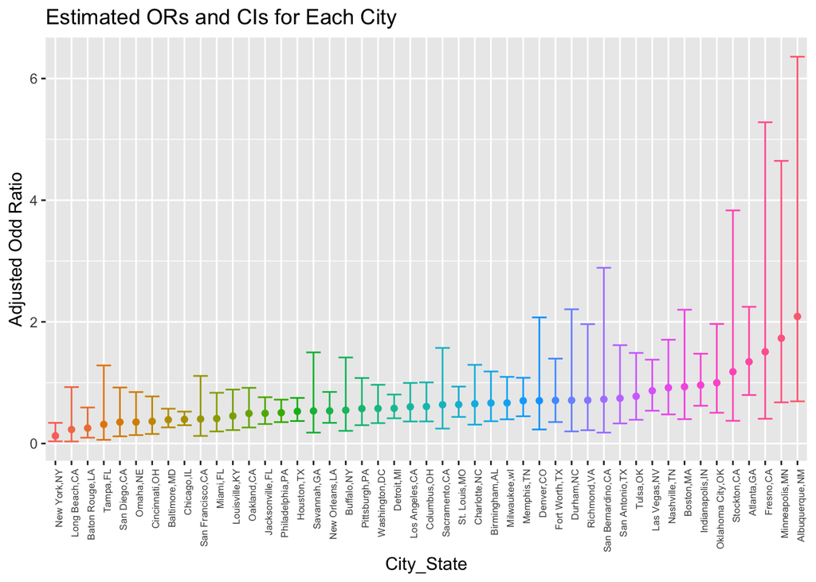

```r
homicide_plot<-
homicide_all_cities %>%
  mutate(
    city_state = fct_reorder(city_state, adjusted_odd_ratio)
  ) %>%
  ggplot(aes(x = city_state, y = adjusted_odd_ratio, color = city_state)) +
  geom_point() +
  geom_errorbar(aes(ymin = conf_low, ymax = conf_high)) +
  theme(legend.position = "none") +
  theme(axis.text.x = element_text(size=6, angle=90, hjust = 1)) +
  labs(
    x = "City_State",
    y = "Adjusted Odd Ratio",
    title = "Estimated ORs and CIs for Each City"
  )
homicide_plot
```

comments: when we only investigate the solved homicides amongh the female and male in each city, we found that the adjusted odd ratio is generally lower than one, so we could concluded that the homicides is less likely to be solved when the victim is male. The city with the lowest adjusted odd ratio included New York,NY, Long Beach,CA, and Baton Rouge, LA. in contrast, the city with the highest adjusted odd ratio included Albuquerque, MM, Minneapolis, MN, and Fresno, CA.

## Problem 3

will analyze data gathered to understand the effects of several variables on a child’s birthweight. This dataset, available here, consists of roughly 4000 children and includes the following variables:

babysex: baby’s sex (male = 1, female = 2) bhead: baby’s head circumference at birth (centimeters) blength: baby’s length at birth (centimeteres) bwt: baby’s birth weight (grams) delwt: mother’s weight at delivery (pounds) fincome: family monthly income (in hundreds, rounded) frace: father’s race (1 = White, 2 = Black, 3 = Asian, 4 = Puerto Rican, 8 = Other, 9 = Unknown) gaweeks: gestational age in weeks malform: presence of malformations that could affect weight (0 = absent, 1 = present) menarche: mother’s age at menarche (years) mheigth: mother’s height (inches) momage: mother’s age at delivery (years) mrace: mother’s race (1 = White, 2 = Black, 3 = Asian, 4 = Puerto Rican, 8 = Other) parity: number of live births prior to this pregnancy pnumlbw: previous number of low birth weight babies pnumgsa: number of prior small for gestational age babies ppbmi: mother’s pre-pregnancy BMI ppwt: mother’s pre-pregnancy weight (pounds) smoken: average number of cigarettes smoked per day during pregnancy wtgain: mother’s weight gain during pregnancy (pounds)

Stage1:Load the raw data

```r
raw_data2<-read.csv(file = "./data/birthweight.csv")
```

clean the data for regression analysis 1. convert categorical variable from numeric type to factor: babysex,frace,malform,mrace 2.check the missing value 3. I found that there are actual only have one value in pnumlbw, and pnumsga, which will not contribute to modelling procedure, so I remove these out of the clean dataset.

```r
clean_data<-
  raw_data2%>%
  mutate(
    babysex=as.factor(babysex),
    frace=as.factor(frace),
    malform=as.factor(malform),
    mrace=as.factor(mrace)
  )%>%
  drop_na()%>%
  select(-pnumlbw,-pnumsga)
```

propose a regression model for birthweight.

I want to choose the potential correlated variables based on the corrplot, but corrplot only available for numeric variables. So I generated a new clean data set, which is similiar as the clean_data above except the variable type is numeric for each variable.

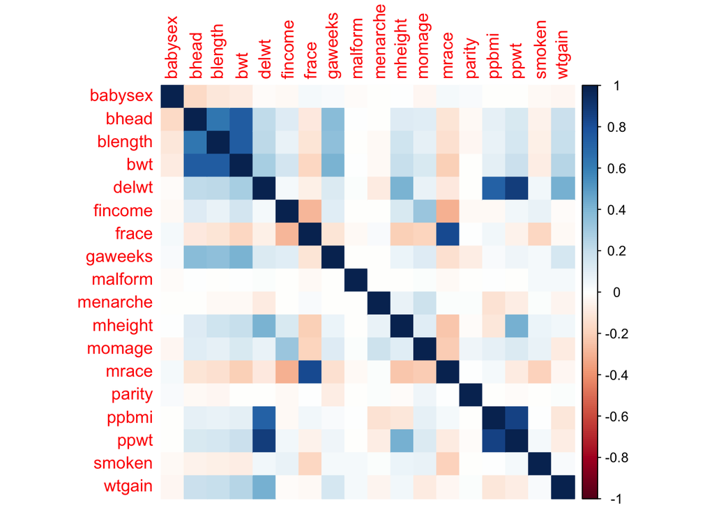

```r
require(corrplot)
clean_data2<-
  raw_data2%>%
  janitor::clean_names()%>%
  select(-pnumlbw,-pnumsga)%>%
  drop_na()
corrplot(cor(clean_data2),method='color',order='alphabet')
```

```r
model_1<-lm(bwt ~ bhead+blength+gaweeks+frace+mrace, data = clean_data)
summary(model_1)
```

```
##
## Call:
## lm(formula = bwt ~ bhead + blength + gaweeks + frace + mrace,
##     data = clean_data)
##
## Residuals:
##      Min       1Q   Median       3Q      Max
## -1133.84  -185.32    -7.61   179.06  2481.30
##
## Coefficients:
##              Estimate Std. Error t value Pr(>|t|)
## (Intercept) -5834.623     98.291 -59.361  < 2e-16 ***
## bhead         135.407      3.477  38.943  < 2e-16 ***
## blength        79.696      2.047  38.932  < 2e-16 ***
## gaweeks        12.381      1.487   8.327  < 2e-16 ***
## frace2         40.795     47.291   0.863 0.388390
## frace3         41.552     71.194   0.584 0.559488
## frace4        -24.136     45.830  -0.527 0.598469
## frace8        -11.440     76.042  -0.150 0.880420
## mrace2       -160.959     47.198  -3.410 0.000655 ***
## mrace3       -132.077     73.618  -1.794 0.072867 .
## mrace4        -98.414     46.147  -2.133 0.033013 *
## ---
## Signif. codes:  0 '***' 0.001 '**' 0.01 '*' 0.05 '.' 0.1 ' ' 1
##
## Residual standard error: 280.2 on 4331 degrees of freedom
## Multiple R-squared:  0.7013, Adjusted R-squared:  0.7006
## F-statistic:  1017 on 10 and 4331 DF,  p-value: < 2.2e-16
```

show a plot of model residuals against fitted values- use add_predictions and add_residuals in making this plot .

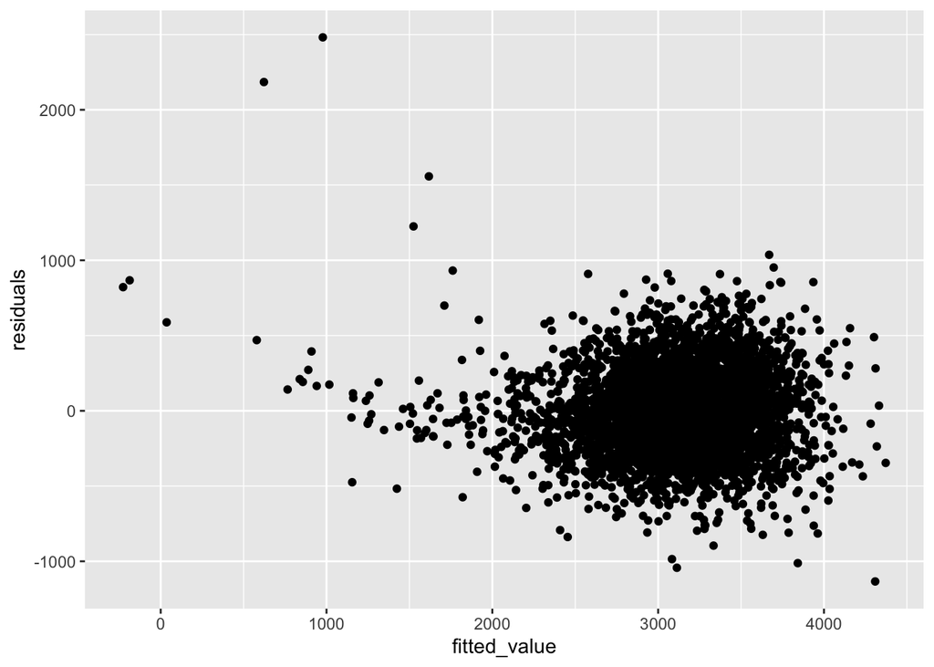

```r
clean_data%>%
  add_residuals(model_1)%>%
  add_predictions(model_1)%>%
  ggplot(aes(x=pred,y=resid))+
  geom_point()+
  geom_smooth(method="lm",color="red")%>%
  labs(
    x="fitted_value",
    y="residuals"
  )
```

compare my model to two others

One using length at birth and gestational age as predictors (main effects only) One using head circumference, length, sex, and all interactions (including the three-way interaction) between these

```r
model_2<-lm(bwt~blength+gaweeks,data=clean_data)
model_3<-lm(bwt~bhead+blength+babysex+bhead*blength+blength*babysex+bhead*babysex+bhead*babysex*blength,data=clean_data)
```

Make this comparison in terms of the cross-validated prediction error; use crossv_mc and functions in purrr as appropriate.

```r
cv_df =
  crossv_mc(clean_data, 100) %>%
  mutate(
    train = map(train, as_tibble),
    test = map(test, as_tibble))
```

Next I’ll use mutate + map & map2 to fit models to training data and obtain corresponding RMSEs for the testing data.

```r
cv_df =
  cv_df %>%
  mutate(
    model_1  = map(train, ~lm(bwt ~ bhead+blength+gaweeks+frace+mrace, data = .x)),
    model_2  = map(train, ~lm(bwt~blength+gaweeks, data = .x)),
    model_3  = map(train, ~lm(bwt~bhead+blength+babysex+bhead*blength+blength*babysex+bhead*babysex+bhead*babysex*blength, data = .x))) %>%
  mutate(
    rmse_model_1 = map2_dbl(model_1, test, ~rmse(model = .x, data = .y)),
    rmse_model_2 = map2_dbl(model_2, test, ~rmse(model = .x, data = .y)),
    rmse_model_3 = map2_dbl(model_3, test, ~rmse(model = .x, data = .y)))
```

Finally, I’ll plot the prediction error distribution for each candidate model.

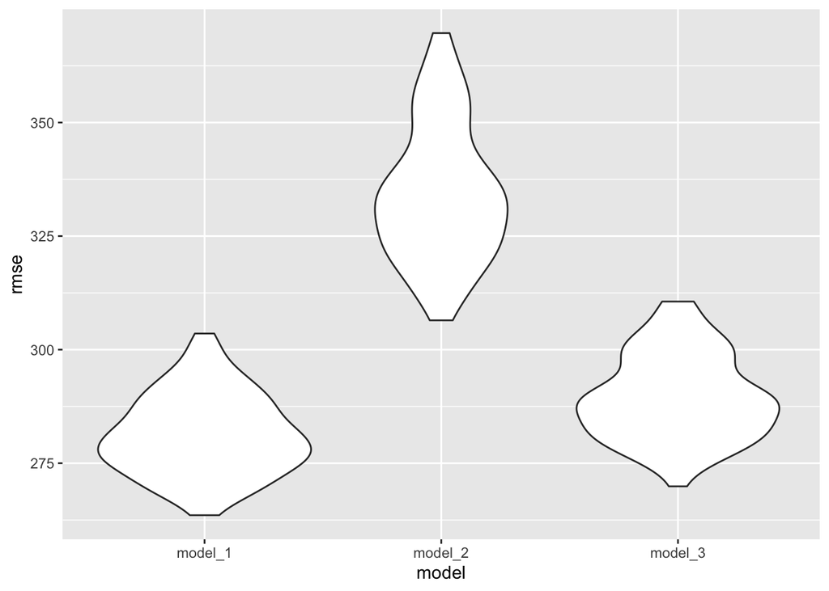

```r
cv_df %>%
  select(starts_with("rmse")) %>%
  pivot_longer(
    everything(),
    names_to = "model",
    values_to = "rmse",
    names_prefix = "rmse_") %>%
  mutate(model = fct_inorder(model)) %>%
  ggplot(aes(x = model, y = rmse)) + geom_violin()
```

Based on the plot above, we can conclude that the model 1 have lower rmse than model 2 and model 3. So, we can assume that the model 1 is the most optimal model in these three models.